# US Health Expenditure Analysis

#### Checking Hetrosedascticity

From residual vs fitted scatter plot we can little quadtratic relationship, also can sense some hetrosedascticity since variance of some residuals is significantly different from others.We will perform statistic test to check for hetrosedasticity i.e *Breuch Pagan Test*

```r
# testing hetroscedasticity
bptest(model.fit6)
```

```
##
##  studentized Breusch-Pagan test
##
## data:  model.fit6
## BP = 52.113, df = 20, p-value = 0.0001096
```

Since p value is less sthan 0.05 it suggests hetrosedasticity, we will perform *BOX COX transformation* to remove hetrosedasticity.

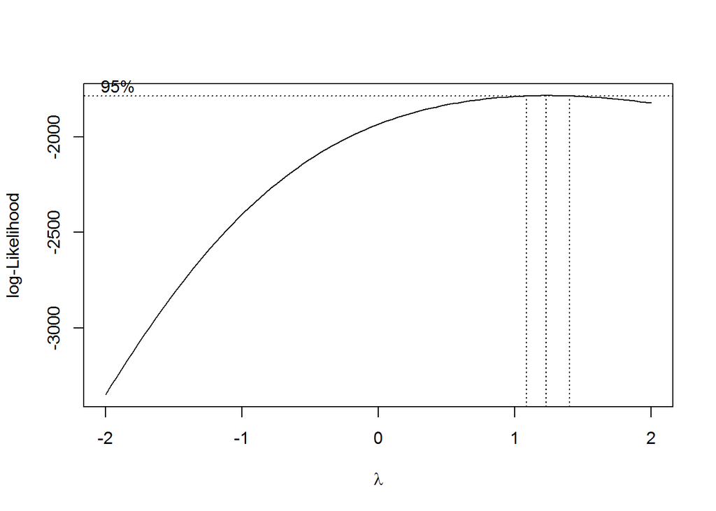

```r
# Remedy of hetroscedasticity BOX COX transformation
bc <- boxcox(lm(log(EXPENDOP) ~ Llag_EXPENDOP + AGE + log(COUNTOP) + famsize +
    factor(insure) + factor(GENDER) + factor(ANYLIMIT) + factor(USC) + PHSTAT +
    RACE + INCOME, data = OppHealth_train))
```

```r
which.max(bc$y)
```

```
## [1] 81
```

```r
lambda <- bc$x[which.max(bc$y)]
lambda
```

```
## [1] 1.232323
```

```r
model.fit7 <- lm(I(log(EXPENDOP)^1.8) ~ Llag_EXPENDOP + AGE + log(COUNTOP) +
    famsize + factor(insure) + factor(GENDER) + factor(ANYLIMIT) + factor(USC) +
    PHSTAT + RACE + INCOME, data = OppHealth_train)
summary(model.fit7)
```

```
##
## Call:
## lm(formula = I(log(EXPENDOP)^1.8) ~ Llag_EXPENDOP + AGE + log(COUNTOP) +
##     famsize + factor(insure) + factor(GENDER) + factor(ANYLIMIT) +
##     factor(USC) + PHSTAT + RACE + INCOME, data = OppHealth_train)
##
## Residuals:
##      Min       1Q   Median       3Q      Max
## -21.6703  -5.1942  -0.9123   3.9529  31.2124
##
## Coefficients:
##                   Estimate Std. Error t value Pr(>|t|)
## (Intercept)        7.15550    2.00211   3.574 0.000367 ***
## Llag_EXPENDOP      0.32997    0.15383   2.145 0.032176 *
## AGE                0.08093    0.02005   4.037 5.81e-05 ***
## log(COUNTOP)       7.88315    0.24576  32.077  < 2e-16 ***
## famsize           -0.01376    0.15470  -0.089 0.929138
## factor(insure)1    2.93593    0.73815   3.977 7.44e-05 ***
## factor(GENDER)1   -0.78940    0.50639  -1.559 0.119326
## factor(ANYLIMIT)1  0.57778    0.60717   0.952 0.341524
## factor(USC)1      -0.26389    0.66205  -0.399 0.690270
## PHSTATFAIR         1.61502    0.93485   1.728 0.084357 .
## PHSTATGOOD         0.44311    0.69534   0.637 0.524090
## PHSTATPOOR         2.99391    1.30374   2.296 0.021847 *
## PHSTATVGOO         0.70309    0.67040   1.049 0.294524
## RACEBLACK          2.51577    1.32424   1.900 0.057732 .
## RACENATIV          6.00346    2.56931   2.337 0.019645 *
## RACEOTHER          1.92607    2.09353   0.920 0.357775
## RACEWHITE          2.28290    1.19128   1.916 0.055590 .
## INCOMELINCOME      1.24553    0.78596   1.585 0.113325
## INCOMEMINCOME      1.01463    0.61653   1.646 0.100123
## INCOMENPOOR       -0.26110    1.15162  -0.227 0.820679
## INCOMEPOOR         1.44843    0.81046   1.787 0.074196 .
## ---
## Signif. codes:  0 '***' 0.001 '**' 0.01 '*' 0.05 '.' 0.1 ' ' 1
##
## Residual standard error: 7.835 on 1061 degrees of freedom
## Multiple R-squared:  0.6023, Adjusted R-squared:  0.5948
## F-statistic: 80.33 on 20 and 1061 DF,  p-value: < 2.2e-16
```

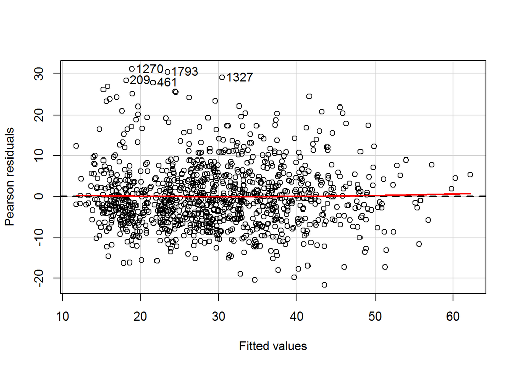

```r
residualPlot(model.fit7, id.n = 5)
```

```r
# testing hetroscedasticity bptest(model.fit7)
```

From residual vs fitted graph we can now observe straight line hence confirming linearity of our regression and also confirming homosedascticity in our new model **model.fit7**

#### Checking normalization of residuals

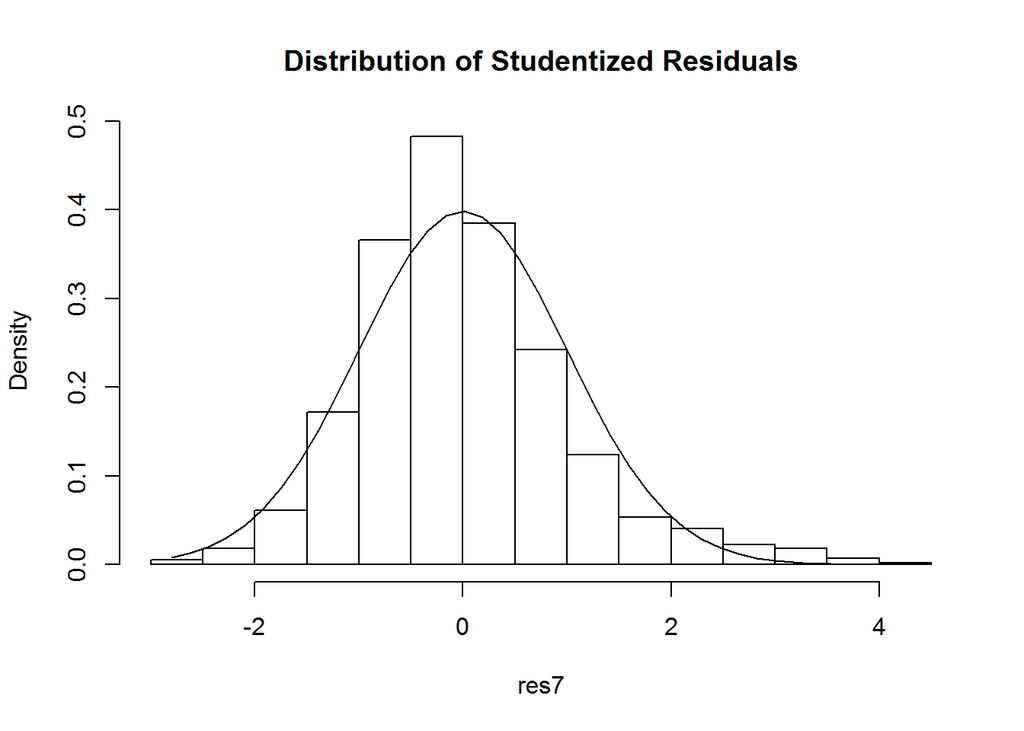

```r
res7 <- studres(model.fit7)
hist(res7, freq = FALSE, main = "Distribution of Studentized Residuals")
xfit <- seq(min(res7), max(res7), length = 40)
yfit <- dnorm(xfit)
lines(xfit, yfit)
```

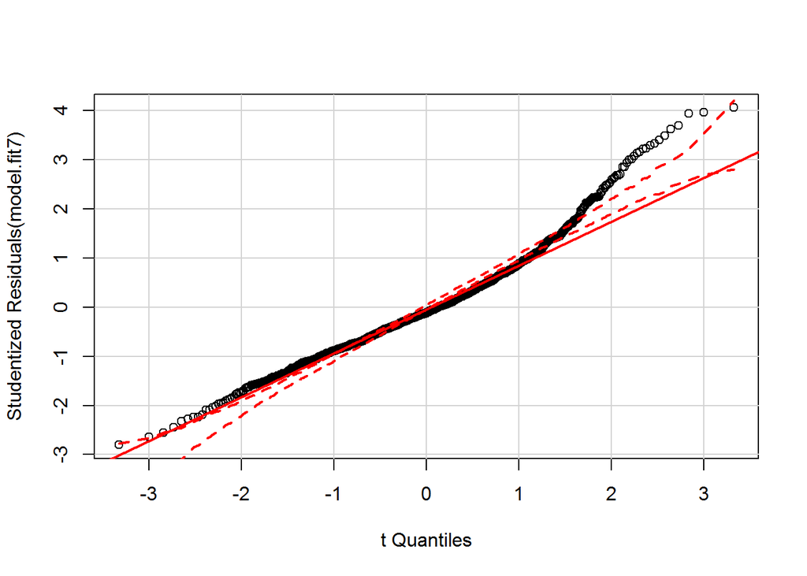

```r
qqPlot(model.fit7)
```

From both the plots we can see that residuals are mostly normally distributed however somewhat rightly skewed because of some outliers might be.

#### Outliers Detection

We will detect outliers using cook’s distance method

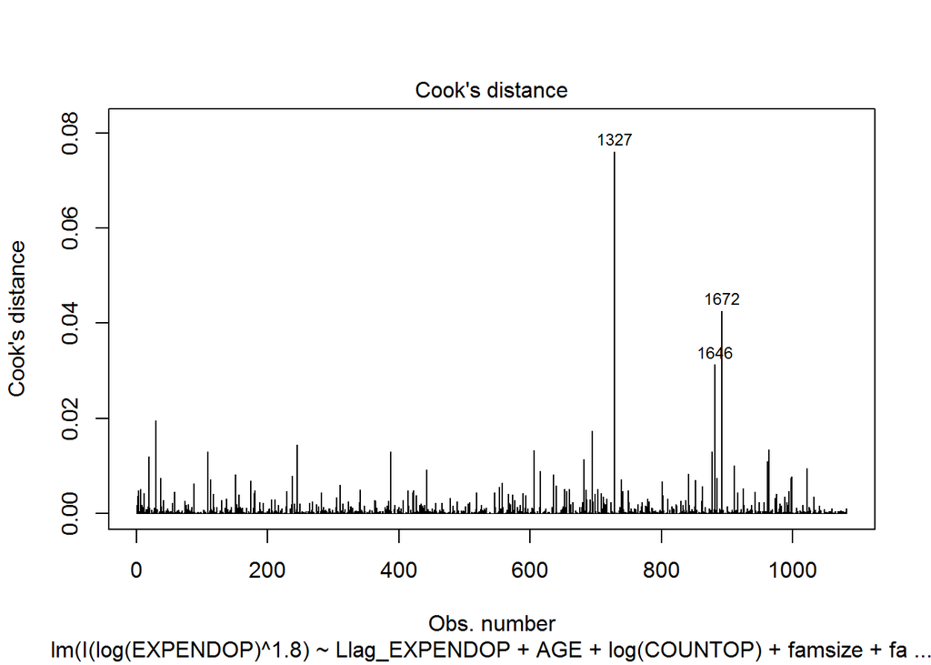

```r
cutoff <- 4/((nrow(OppHealth_train) - length(model.fit7$coefficients) - 2))
plot(model.fit7, which = 4, cook.levels = cutoff)
```

#### Testing final model

We tested our final model using **PRESS** statistics

```r
library(qpcR)
PRESS(model.final)$P.square
```

[output not shown]

```
## [1] -102156.3
```

##### Fitting model on full data

```r
detach(newophealth)
attach(OppHealth)
Lllag_EXPENDOP <- c(0)
for (i in 2:nrow(OppHealth)) {
    Lllag_EXPENDOP[i] <- log(OppHealth$EXPENDOP[i - 1])
}


m <- lm(I(log(EXPENDOP)^1.8) ~ Lllag_EXPENDOP + AGE + log(COUNTOP) + famsize +
    factor(insure) + factor(GENDER) + factor(ANYLIMIT) + factor(USC) + PHSTAT +
    RACE + INCOME, data = OppHealth)

summary(m)
```

```
##
## Call:
## lm(formula = I(log(EXPENDOP)^1.8) ~ Lllag_EXPENDOP + AGE + log(COUNTOP) +
##     famsize + factor(insure) + factor(GENDER) + factor(ANYLIMIT) +
##     factor(USC) + PHSTAT + RACE + INCOME, data = OppHealth)
##
## Residuals:
##     Min      1Q  Median      3Q     Max
## -22.528  -5.138  -0.798   4.079  31.714
##
## Coefficients:
##                   Estimate Std. Error t value Pr(>|t|)
## (Intercept)        8.82376    1.85638   4.753 2.22e-06 ***
## Lllag_EXPENDOP     0.16384    0.13780   1.189 0.234647
## AGE                0.06990    0.01794   3.897 0.000102 ***
## log(COUNTOP)       8.01407    0.21955  36.502  < 2e-16 ***
## famsize           -0.03848    0.14043  -0.274 0.784145
## factor(insure)1    2.47060    0.66301   3.726 0.000202 ***
## factor(GENDER)1   -1.17836    0.45172  -2.609 0.009193 **
## factor(ANYLIMIT)1  0.24390    0.54041   0.451 0.651836
## factor(USC)1      -0.17173    0.57918  -0.297 0.766887
## PHSTATFAIR         2.20879    0.84452   2.615 0.009012 **
## PHSTATGOOD         0.84332    0.62324   1.353 0.176242
## PHSTATPOOR         3.04256    1.13051   2.691 0.007206 **
## PHSTATVGOO         0.73278    0.60091   1.219 0.222890
## RACEBLACK          2.92232    1.21331   2.409 0.016151 *
## RACENATIV          6.19919    2.19982   2.818 0.004903 **
## RACEOTHER          2.30140    1.85734   1.239 0.215532
## RACEWHITE          2.72605    1.09632   2.487 0.013021 *
## INCOMELINCOME      1.05707    0.71020   1.488 0.136878
## INCOMEMINCOME      0.71570    0.55291   1.294 0.195743
## INCOMENPOOR       -0.75644    1.03214  -0.733 0.463759
## INCOMEPOOR         1.41893    0.72489   1.957 0.050506 .
## ---
## Signif. codes:  0 '***' 0.001 '**' 0.01 '*' 0.05 '.' 0.1 ' ' 1
##
## Residual standard error: 7.831 on 1331 degrees of freedom
## Multiple R-squared:  0.5994, Adjusted R-squared:  0.5934
## F-statistic: 99.59 on 20 and 1331 DF,  p-value: < 2.2e-16
```

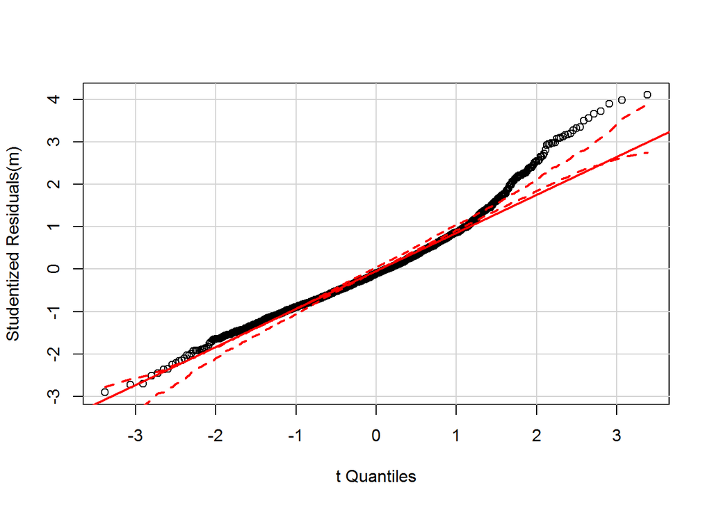

```r
qqPlot(m)
```

### Conclusion

From our best model we were able to explain only 60%, lots more left to be explained. However, we could say that age, number of times person was a out patient, whether he has any health coverage or not are playing important in deciding his health expenditure as a outpatient. Apart from these factors gender, physical state, race and income can also decide to some extent variablity in expenditure.

We might need more data to capture more variablity in the expenditure.